# The Elo method in chess

**Elo method** was coined by the physics professor and excellent chess player Arpad Elo. In 1970, FIDE, the World Chess Federation, agreed to adopt the Elo Rating System.

The method works as follows. Suppose that players $i$ and $j$ match. Let $s_{i,j}$ be the **actual score** of $i$ in the match against $j$. We have that:

- $s_{i,j} = 1$ if $i$ wins;
- $s_{i,j} = 0$ if $i$ loses; and
- $s_{i,j} = 0.5$ if there is a draw.

Notice that the actual score $s_{j,i}$ of $j$ in the match against $i$ is $1 - s_{i,j}$. Let $\mu_{i,j}$ be the **expected score** of $i$ in the match against $j$. We have that:

$$\begin{array}{lll}
\mu_{i,j} & = & \frac{1}{1 + 10^{-(r_i - r_j) / \zeta}} =
\frac{10^{r_i / \zeta}}{10^{r_i / \zeta} + 10^{r_j / \zeta}} \\\\
\end{array}$$

with $r_i$ and $r_j$ the ratings of $i$ and $j$ before the match and $\zeta$ is a constant. Notice that the expected score $\mu_{j,i}$ of $j$ in the match against $i$ is $1 - \mu_{i,j}$.

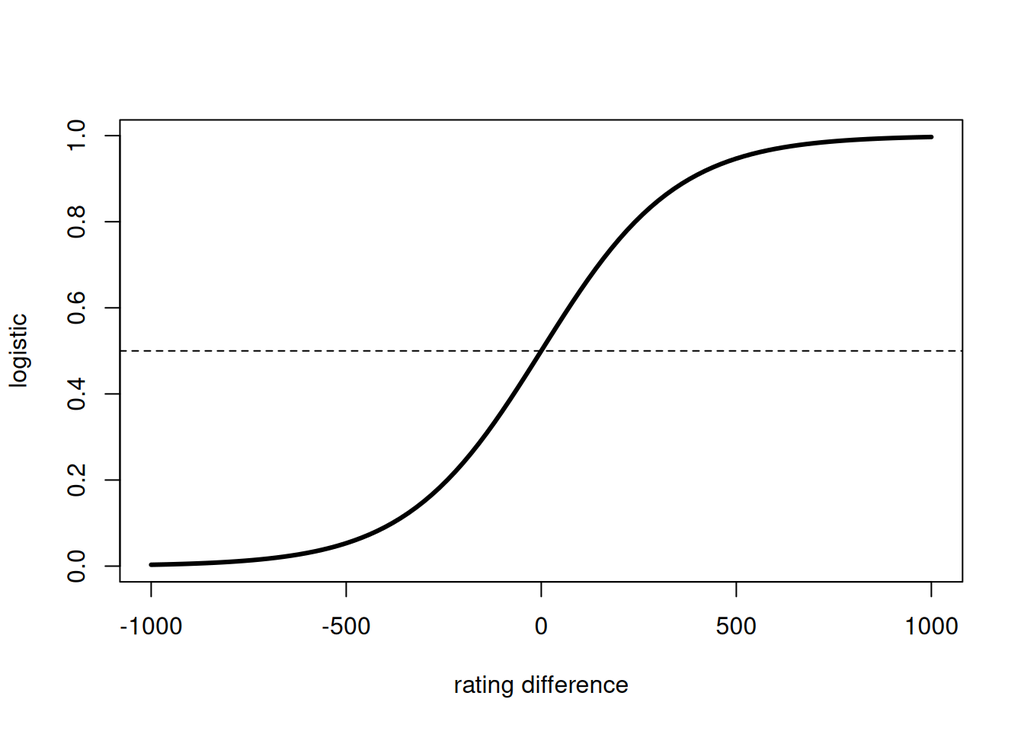

We assume that initially all player ratings are equal to 0. When players $i$ and $j$ match, the new ratings $r_i$ of $i$ and $r_j$ of $j$ are modified using the following update rule:

$$\begin{array}{lll}
r_{i} & \leftarrow & r_i + \kappa (s_{i,j} - \mu_{i,j})
\\
r_j & \leftarrow & r_j + \kappa (s_{j,i} - \mu_{j,i})
\end{array}$$

where $\kappa$ is a constant.

The Elo thesis is:

> *If a player performs as expected, it gains nothing. If it performs better than expected, it is rewarded, while if it performs poorer than expected, it is penalized.*

This challenge is ispired by [Chess ratings - Elo versus the Rest of the World](https://www.kaggle.com/c/chess#description) Kaggle competition.

## Downloads

- A CSV with outcomes of 65053 distinct chess games (White, Black and Score). The possible values for Score represent the three possible outcomes of a chess game (1=White wins, 0.5=draw, 0=Black wins). Read [details](https://www.kaggle.com/c/chess/data).

## Challenges

1. Has the White an advantage over the Black, that is, is there a first-mover advantage?

```r
library(dplyr)
library(ggplot2)
games = read.csv("data.csv")
if ("Month" %in% names(games)) games = arrange(games, Month)
str(games)
```

```
## 'data.frame':    65053 obs. of  3 variables:
##  $ White: int  73 73 73 73 73 88 88 88 154 158 ...
##  $ Black: int  1246 5097 5104 7321 7375 1033 1860 4858 3377 8059 ...
##  $ Score: num  0.5 0.5 0.5 1 0.5 0.5 1 1 0 1 ...
```

```r
table(games$Score) / nrow(games)
```

```
##
##         0       0.5         1
## 0.2340246 0.4406561 0.3253194
```

```r
mean(games$Score)
```

```
## [1] 0.5456474
```

```r
# 0.5 = nessun vantaggio
# test sulle sole partite con un vincitore
decisive = filter(games, Score != 0.5)
binom.test(sum(decisive$Score == 1), nrow(decisive), p = 0.5)
```

```
##
##  Exact binomial test
##
## data:  sum(decisive$Score == 1) and nrow(decisive)
## number of successes = 21163, number of trials = 36387, p-value <
## 2.2e-16
## alternative hypothesis: true probability of success is not equal to 0.5
## 95 percent confidence interval:
##  0.5765202 0.5866844
## sample estimates:
## probability of success
##              0.5816088
```

Il punteggio medio del bianco è superiore a 0.5. Considerando solo le partite decisive, il bianco vince significativamente più spesso del Nero (p-value del test binomiale è circa 0). Esiste quindi un vantaggio della prima mossa.

2. Write a function that computes the player point rating (1 point for wins, 0.5 points for draws, 0 points for defeats). How are point ratings distributed? Why?

```r
point_rating = function(games) {
  bind_rows(
    tibble(player = games$White, s = games$Score),
    tibble(player = games$Black, s = 1 - games$Score)
  ) %>%
    group_by(player) %>%
    summarise(points = sum(s), games = n())
}
pts = point_rating(games)
summary(pts$points)
```

```
##    Min. 1st Qu.  Median    Mean 3rd Qu.    Max.
##    0.00    1.00    3.00    8.91    9.00  167.50
```

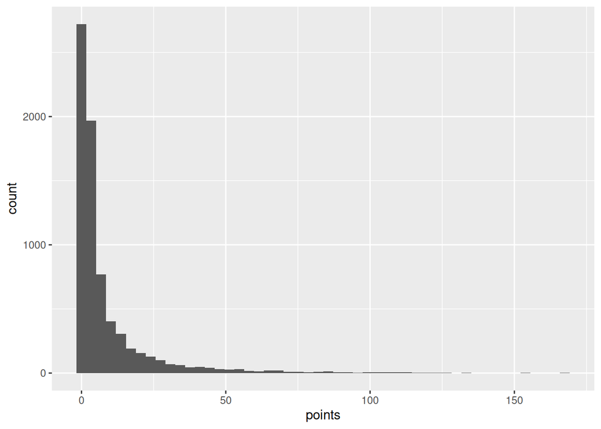

```r
ggplot(pts, aes(points)) + geom_histogram(bins = 50)
```

La distribuzione è asimmetrica a destra e questo significa che la maggior parte dei giocatori ha pochi punti e pochi giocatori hanno tanti punti. I punti sono cumulativi, quindi riflettono soprattutto quante partite ha giocato un giocatore. Anche il numero di partite per giocatore è asimmetrico: ci sono molti giocatori occasionali e pochi giocatori molto attivi.

4. Write a function that computes the player Elo rating (set $\zeta = 400$ and $\kappa = 25$) (Hint: take advantage of the 0-sum property to optimize the code). Obserse its distribution: why is different from the point distribution? Verify the 0-sum property for Elo’s ratings

```r
elo_rating = function(games, z = 400, k = 25) {
  players = sort(unique(c(games$White, games$Black)))
  w = match(games$White, players)
  b = match(games$Black, players)
  r = rep(0, length(players))
  for (g in seq_len(nrow(games))) {
    i = w[g]; j = b[g]
    mu = 1 / (1 + 10^(-(r[i] - r[j]) / z))
    delta = k * (games$Score[g] - mu)
    r[i] = r[i] + delta
    r[j] = r[j] - delta   #variazione di j è opposta a quella di i
  }
  tibble(player = players, elo = r)
}
elo = elo_rating(games)
summary(elo$elo)
```

```
##     Min.  1st Qu.   Median     Mean  3rd Qu.     Max.
## -146.456  -22.873   -6.005    0.000   12.476  326.950
```

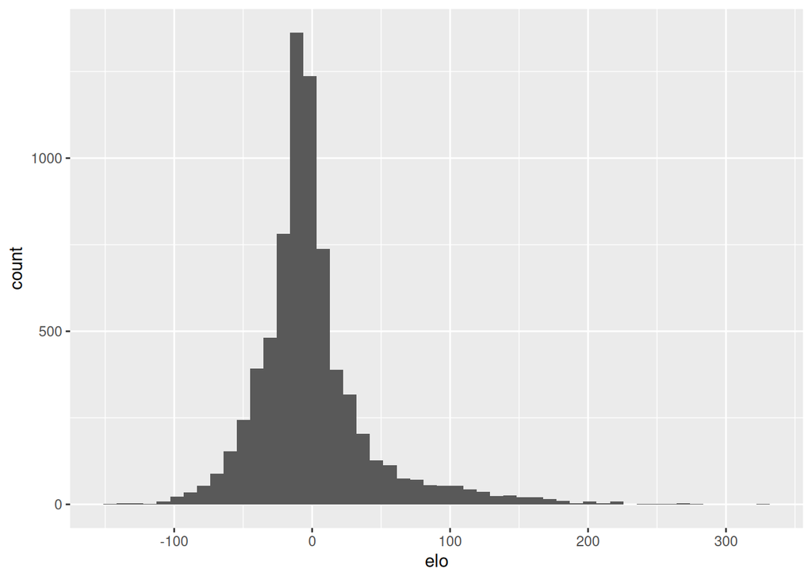

```r
ggplot(elo, aes(elo)) + geom_histogram(bins = 50)
```

```r
sum(elo$elo)
```

```
## [1] 9.049983e-13
```

La distribuzione Elo è approssimativamente a campana e centrata sullo 0. Elo un giocatore guadagna solo se fa meglio del previsto, quindi giocare molte partite non fa crescere direttamente il rating. La somma dei rating Elo è comunque 0.

5. Are point and Elo ratings correlated? Are top Elo players overlapping with top point players?

```r
ratings = inner_join(pts, elo, by = "player")
cor(ratings$points, ratings$elo)
```

```
## [1] 0.7198872
```

```r
cor(ratings$points, ratings$elo, method = "spearman")
```

```
## [1] 0.406949
```

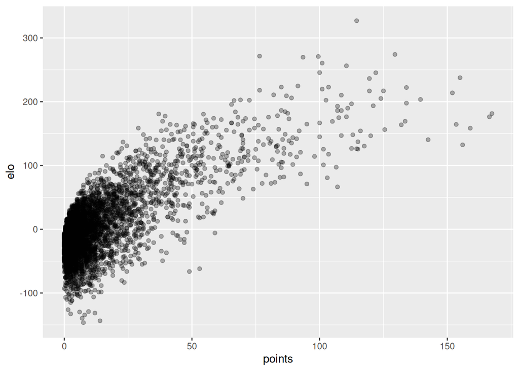

```r
ggplot(ratings, aes(points, elo)) + geom_point(alpha = 0.3)
```

```r
n = 20
top_points = slice_max(ratings, points, n = n)$player
top_elo    = slice_max(ratings, elo, n = n)$player
length(intersect(top_points, top_elo))
```

```
## [1] 6
```

I due rating sono correlati positivamente, ma non in modo perfetto infatti le due top 20 si sovrappongono solo in parte. Possiamo notare che i migliori per punti sono spesso giocatori con moltissime partite invece i migliori per Elo sono quelli che battono avversari forti.

6. Test if the number of played games has an effect on the Elo and point player ratings

```r
cor.test(ratings$games, ratings$points)
```

```
##
##  Pearson's product-moment correlation
##
## data:  ratings$games and ratings$points
## t = 602.15, df = 7299, p-value < 2.2e-16
## alternative hypothesis: true correlation is not equal to 0
## 95 percent confidence interval:
##  0.9896209 0.9905267
## sample estimates:
##       cor
## 0.9900841
```

```r
cor.test(ratings$games, ratings$elo)
```

```
##
##  Pearson's product-moment correlation
##
## data:  ratings$games and ratings$elo
## t = 70.934, df = 7299, p-value < 2.2e-16
## alternative hypothesis: true correlation is not equal to 0
## 95 percent confidence interval:
##  0.6250135 0.6521762
## sample estimates:
##       cor
## 0.6387939
```

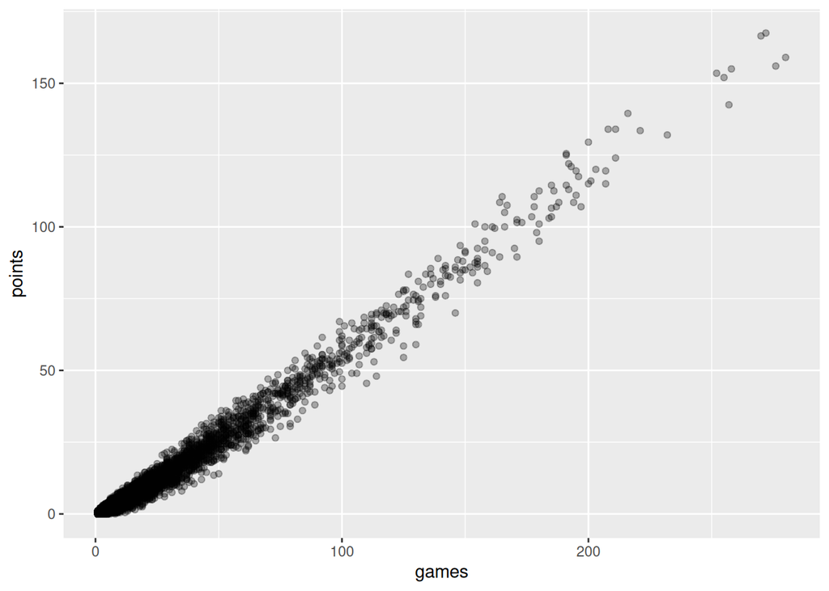

```r
ggplot(ratings, aes(games, points)) + geom_point(alpha = 0.3)
```

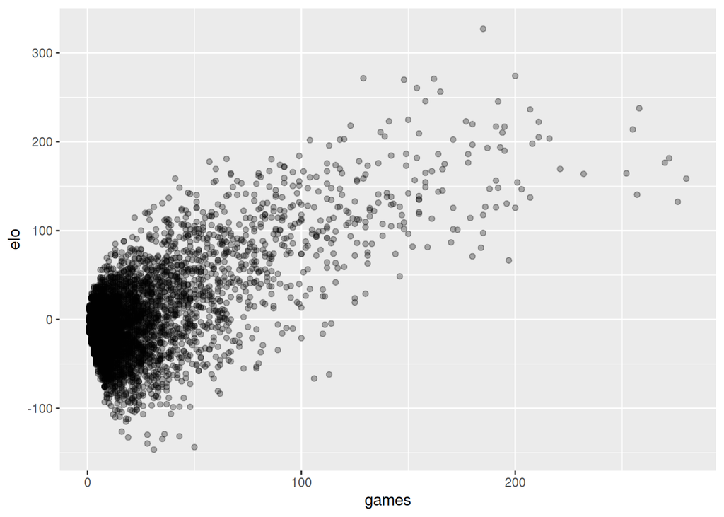

```r
ggplot(ratings, aes(games, elo)) + geom_point(alpha = 0.3)
```